# 10. 回帰分析 2 (ダミー変数)宿題模範解答

Masahiko Asano

2020-07-05

# 3. 宿題

[・hr96_14.csv](http://www.ner.takushoku-u.ac.jp/masano/class_material/waseda/keiryo/hr96_14.csv) は1996年に衆院選挙に小選挙区が導入されて以来実施された 7 回の衆議院選挙（1996, 2000, 2003, 2005, 2009, 2012, 2014）の結果のデータである。

・このデータの中から2005年の衆議院選挙データだけ取り出し、次の三つの変数 (voteshare, exppv, jcp) を使って重回帰分析を行いなさい。

**voteshare** : 得票率（応答変数）  
**exppv** :有権者一人当たりに候補者が費やした選挙費用（説明変数）  
**jcp** : 共産党ダミー（共産党候補者 = 1、それ以外 = 0）

**各20点（100点満点）**

Q1: `stargazer()`を使って、2005年の衆議院選挙の三つの変数 (voteshare, exppv, jcp) の記述統計を表示させなさい。

Q2: exppv と voteshare の散布図を描きなさい。その際、回帰直線も表示すること。

Q3: jcp と voteshare の散布図を描きなさい。その際、回帰直線も表示すること。

Q4: voteshare を応答変数、exppv と jcp を説明変数とした重回帰分析を実行し、その重回帰式を示し、重回帰分析結果を解釈しなさい。

Q5: voteshare を応答変数、exppv と jcp を説明変数とした散布図を描きなさい。その際、観測値と回帰直線はダミー変数 (jcp) で色分けすること。 （白黒で描く場合には、散布図のドットの形を変えたり、回帰直線の種類を二種類使うこと）

# 模範解答

## Q1: `stargazer()`を使って、2005年の衆議院選挙の三つの変数 (voteshare, exppv, jcp) の記述統計を表示させなさい。

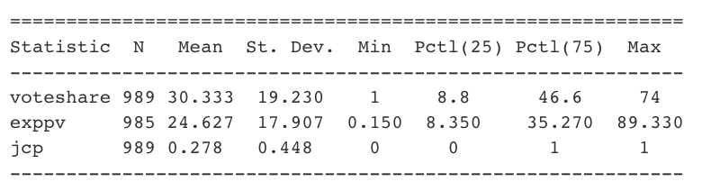

変数一覧

## Q2: exppv と voteshare の散布図を描きなさい。その際、回帰直線も表示すること。

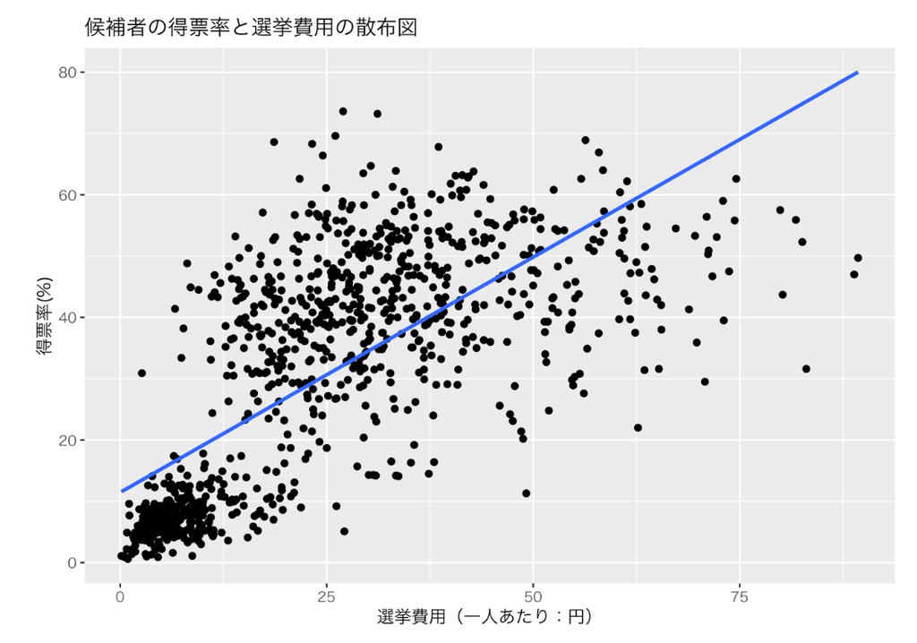

散布図

## Q3: jcp と voteshare の散布図を描きなさい。その際、回帰直線も表示すること。

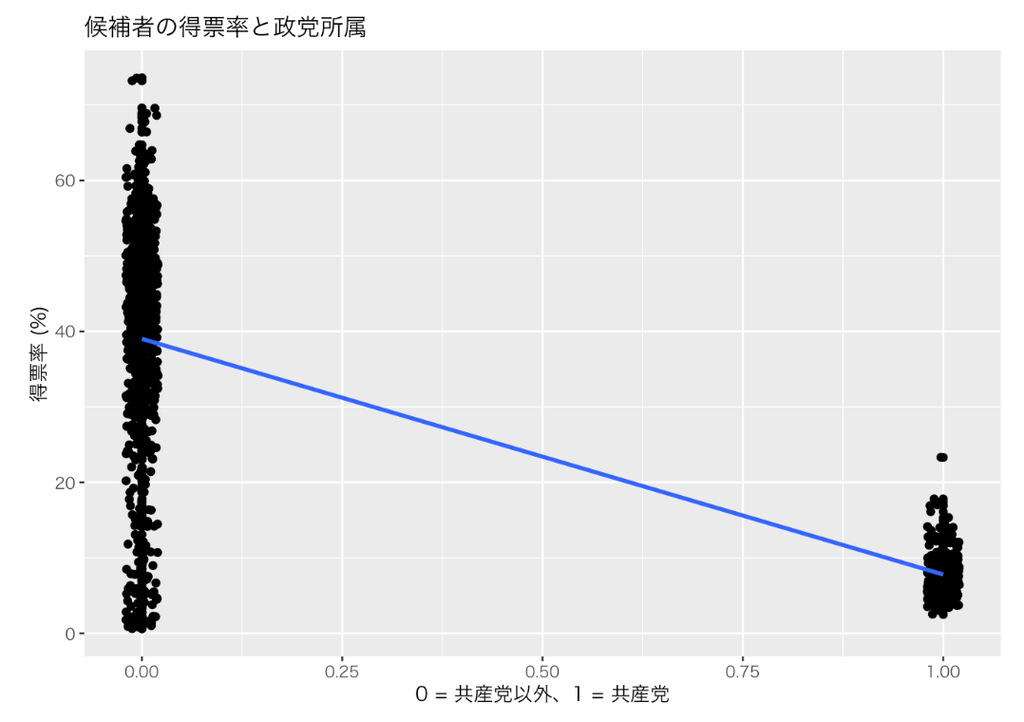

散布図

## Q4: voteshare を応答変数、exppv と jcp を説明変数とした重回帰分析を実行し、その重回帰式を示し、重回帰分析結果を解釈しなさい。

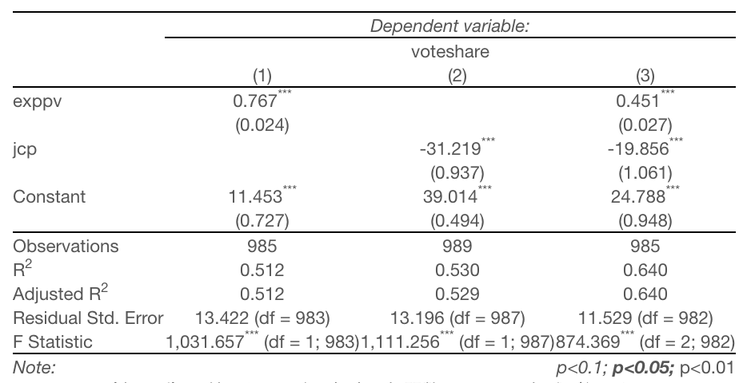

回帰分析結果

[figure not shown]

回帰分析結果

## Q5: voteshare を応答変数、exppv と jcp を説明変数とした散布図を描きなさい。その際、観測値と回帰直線はダミー変数 (jcp) で色分けすること。

（白黒で描く場合には、散布図のドットの形を変えたり、回帰直線の種類を二種類使うこと）

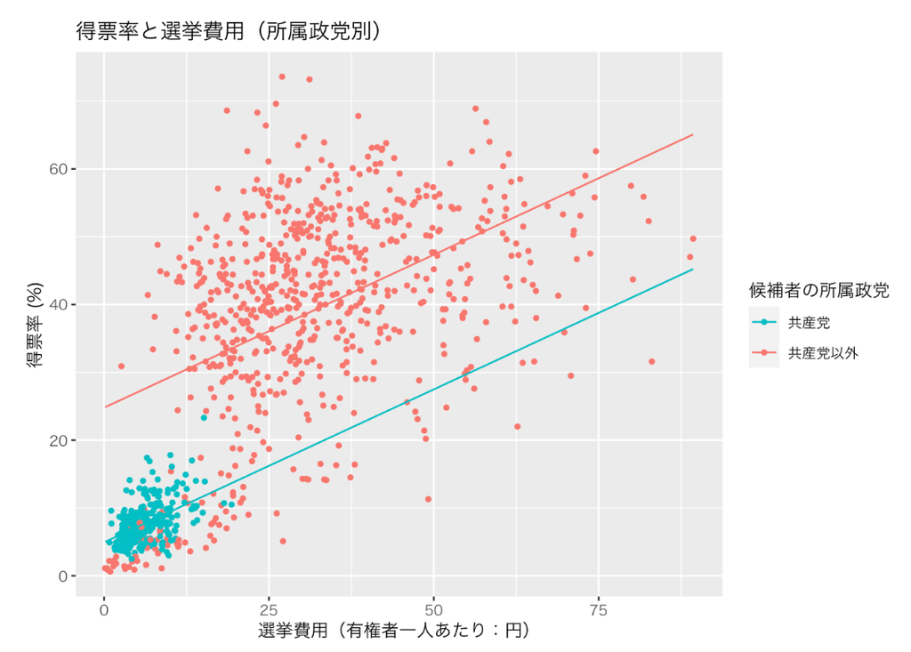

# 解説

・分析に必要なパッケージ `(tidyverse)` をロードする

```r
library(tidyverse)
```

[・hr96_14.csv](http://www.ner.takushoku-u.ac.jp/masano/class_material/waseda/keiryo/hr96_14.csv) をダウンロードし、RProject folder にコピーして read.csv で読み取る。

```r
hr <- read_csv("data/hr96_14.csv", na = ".") # na = "."は欠損処理
```

・hrは1996年に衆院選挙に小選挙区が導入されて以来実施された 7 回の衆議院選挙（1996, 2000, 2003, 2005, 2009, 2012, 2014）の結果のデータである。

・このデータの中から2005年の衆議院選挙データだけ取り出し、次の三つの変数 (voteshare, exppv, jcp) を使って重回帰分析を行ってみる。

**voteshare** : 得票率（応答変数）  
**exppv** :有権者一人当たりに候補者が費やした選挙費用（説明変数）  
**jcp** : 共産党ダミー（共産党候補者 = 1、それ以外 = 0）

・共産党ダミー (jcp) を作る

```r
hr <- mutate(hr,
             jcp = as.numeric(party == "JCP"))
```

```r
head(hr)
```

```
# A tibble: 6 x 22
   year ku      kun party party_code   mag name    age status nocand  rank    wl
  <dbl> <chr> <dbl> <chr>      <dbl> <dbl> <chr> <dbl>  <dbl>  <dbl> <dbl> <dbl>
1  1996 aichi     1 NFP            8     1 KAWA…    47      1      7     1     1
2  1996 aichi     1 LDP            1     1 IMAE…    72      2      7     2     0
3  1996 aichi     1 DPJ            3     1 SATO…    53      1      7     3     0
4  1996 aichi     1 JCP            2     1 IWAN…    43      0      7     4     0
5  1996 aichi     1 othe…        100     1 ITO,…    51      0      7     5     0
6  1996 aichi     1 koku…         22     1 YAMA…    51      0      7     6     0
# … with 10 more variables: previous <dbl>, vote <dbl>, voteshare <dbl>,
#   eligible <dbl>, turnout <dbl>, exp <dbl>, exppv <dbl>, ldp <dbl>,
#   dpj <dbl>, jcp <dbl>
```

```r
hr05 <- hr %>%
  filter(year == 2005) %>%　  　# 2005年のデータだけを選ぶ
  select(voteshare, exppv, jcp) # 三つの変数だけを選ぶ
```

・抜き取ったデータの最初と最後の部分を表示。

```r
head(hr05)
```

```
# A tibble: 6 x 3
  voteshare exppv   jcp
      <dbl> <dbl> <dbl>
1      50   17.0      0
2      39.1 40.0      0
3       7.4  6.05     1
4       3.6 13.1      0
5      52   30.2      0
6      39.1 14.4      0
```

```r
tail(hr05)
```

```
# A tibble: 6 x 3
  voteshare exppv   jcp
      <dbl> <dbl> <dbl>
1      37.5 62.4      0
2      20.2 48.8      0
3       4.3  5.86     1
4      36   44.8      0
5      34.9 56.5      0
6      29   38.3      0
```

・データのサマリーを表示。

```r
summary(hr05)
```

```
   voteshare         exppv            jcp
 Min.   : 0.60   Min.   : 0.15   Min.   :0.0000
 1st Qu.: 8.80   1st Qu.: 8.35   1st Qu.:0.0000
 Median :34.80   Median :22.84   Median :0.0000
 Mean   :30.33   Mean   :24.63   Mean   :0.2781
 3rd Qu.:46.60   3rd Qu.:35.27   3rd Qu.:1.0000
 Max.   :73.60   Max.   :89.33   Max.   :1.0000
                 NA's   :4
```

・`stargazer()`を使って、記述統計を表示。

```r
library("stargazer")
```

```r
stargazer(as.data.frame(hr05), type = "text")
```

```
============================================================
Statistic  N   Mean  St. Dev.  Min  Pctl(25) Pctl(75)  Max
------------------------------------------------------------
voteshare 989 30.333  19.230    1     8.8      46.6     74
exppv     985 24.627  17.907  0.150  8.350    35.270  89.330
jcp       989 0.278   0.448     0      0        1       1
------------------------------------------------------------
```

・exppv と voteshare の散布図を表示。

Mac でggplot2 をそのまま使うと日本語が文字化けする。10 ポイントのヒラギノフォントを使って日本語を正しく表示するために、Mac ユ ーザのみ次のコマンドを実行する。

```r
theme_set(theme_gray(base_size = 10,
                     base_family = "HiraginoSans-W3"))
```

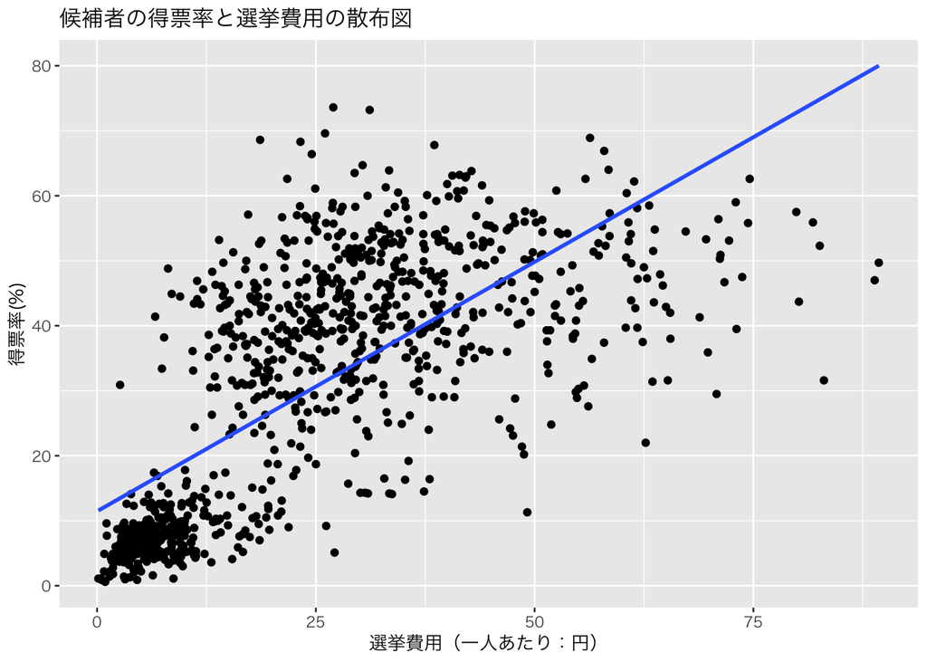

```r
ggplot(hr05, aes(exppv, voteshare)) +
  geom_point() +
  labs(x = "選挙費用（一人あたり：円）", y = "得票率(%)",
         title = "候補者の得票率と選挙費用の散布図") +
  geom_smooth(method = lm, se = FALSE)  # se = FALSE → 95% 信頼区間を消す
```

・jcp と voteshare の散布図を表示。

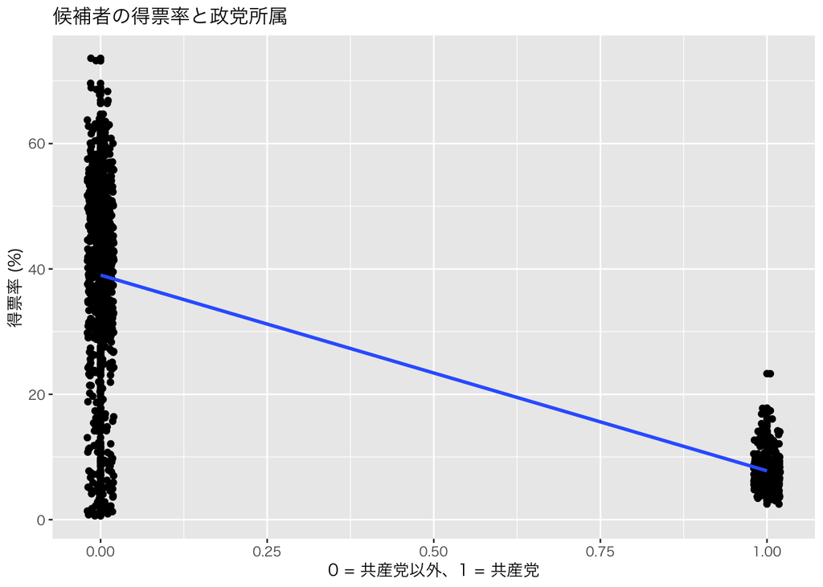

```r
ggplot(hr05, aes(jcp, voteshare)) +
  geom_point() +
  labs(x = "0 = 共産党以外、1 = 共産党", y = "得票率 (%)",
         title = "候補者の得票率と政党所属") +
  geom_jitter(width = 0.02) + # データを散らして表示
  geom_smooth(method = lm, se = FALSE)  # se = FALSE → 95% 信頼区間を消す
```

・次の三種類の回帰分析を行ってみる。

```r
model_1 <- lm(voteshare ~ exppv, data = hr05)
```

・voteshare と jcp の単回帰

```r
model_2 <- lm(voteshare ~ jcp, data = hr05)
```

・voteshare と exppv + jcp の重回帰

```r
model_3 <- lm(voteshare ~ exppv + jcp, data = hr05)
```

・三つのモデルの結果を表示する。  
・`summary()` を使った結果表示

```r
summary(model_1)
```

```
Call:
lm(formula = voteshare ~ exppv, data = hr05)

Residuals:
    Min      1Q  Median      3Q     Max
-43.598  -9.661  -3.493   9.910  42.849

Coefficients:
            Estimate Std. Error t value Pr(>|t|)
(Intercept) 11.45323    0.72743   15.74   <2e-16 ***
exppv        0.76746    0.02389   32.12   <2e-16 ***
---
Signif. codes:  0 '***' 0.001 '**' 0.01 '*' 0.05 '.' 0.1 ' ' 1

Residual standard error: 13.42 on 983 degrees of freedom
  (4 observations deleted due to missingness)
Multiple R-squared:  0.5121,    Adjusted R-squared:  0.5116
F-statistic:  1032 on 1 and 983 DF,  p-value: < 2.2e-16
```

```r
summary(model_2)
```

```
Call:
lm(formula = voteshare ~ jcp, data = hr05)

Residuals:
    Min      1Q  Median      3Q     Max
-38.414  -3.814   0.505   7.686  34.586

Coefficients:
            Estimate Std. Error t value Pr(>|t|)
(Intercept)  39.0139     0.4938   79.00   <2e-16 ***
jcp         -31.2193     0.9365  -33.34   <2e-16 ***
---
Signif. codes:  0 '***' 0.001 '**' 0.01 '*' 0.05 '.' 0.1 ' ' 1

Residual standard error: 13.2 on 987 degrees of freedom
Multiple R-squared:  0.5296,    Adjusted R-squared:  0.5291
F-statistic:  1111 on 1 and 987 DF,  p-value: < 2.2e-16
```

```r
summary(model_3)
```

```
Call:
lm(formula = voteshare ~ exppv + jcp, data = hr05)

Residuals:
    Min      1Q  Median      3Q     Max
-35.664  -4.288   0.326   6.656  36.637

Coefficients:
             Estimate Std. Error t value Pr(>|t|)
(Intercept)  24.78783    0.94755   26.16   <2e-16 ***
exppv         0.45110    0.02659   16.97   <2e-16 ***
jcp         -19.85584    1.06074  -18.72   <2e-16 ***
---
Signif. codes:  0 '***' 0.001 '**' 0.01 '*' 0.05 '.' 0.1 ' ' 1

Residual standard error: 11.53 on 982 degrees of freedom
  (4 observations deleted due to missingness)
Multiple R-squared:  0.6404,    Adjusted R-squared:  0.6397
F-statistic: 874.4 on 2 and 982 DF,  p-value: < 2.2e-16
```

・`stargazer()` を使った結果表示

```r
stargazer(model_1, model_2, model_3, type = "html")
```

|  | *Dependent variable:* |  |  |
| --- | --- | --- | --- |
|  | voteshare |  |  |
|  | (1) | (2) | (3) |
| exppv | 0.767*** |  | 0.451*** |
|  | (0.024) |  | (0.027) |
| jcp |  | -31.219*** | -19.856*** |
|  |  | (0.937) | (1.061) |
| Constant | 11.453*** | 39.014*** | 24.788*** |
|  | (0.727) | (0.494) | (0.948) |
| Observations | 985 | 989 | 985 |
| R<sup>2</sup> | 0.512 | 0.530 | 0.640 |
| Adjusted R<sup>2</sup> | 0.512 | 0.529 | 0.640 |
| Residual Std. Error | 13.422 (df = 983) | 13.196 (df = 987) | 11.529 (df = 982) |
| F Statistic | 1,031.657*** (df = 1; 983) | 1,111.256*** (df = 1; 987) | 874.369*** (df = 2; 982) |
| *Note:* | p<0.1; p<0.05; p<0.01 |  |  |

・model_3（右の列）の結果から、次の標本回帰関数 (SRF) の回帰式が得られる。

$\mathrm{\widehat{voteshare}\ = 24.79 + 0.45exppv - 19.86jcp}$

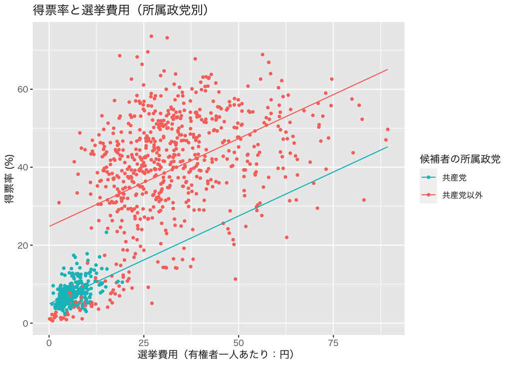

```r
## 予測値のデータフレームを作り pred と名前をつける
pred <- with(hr05, expand.grid(
  exppv = seq(min(exppv, na.rm=TRUE), max(exppv, na.rm=TRUE), length = 100),
  jcp = c(0,1)
))

## mutate を使って、新たな変数である予測値 (pred) を作り計算する
pred <- mutate(pred, voteshare = predict(model_3, newdata = pred))

## 散布図のドット (point) は観測値 (hr05) で描き、回帰直線は予測値 (pred) で描く
p3 <- ggplot(hr05, aes(x = exppv, y = voteshare, color = as.factor(jcp))) +
  geom_point(size = 1) + geom_line(data = pred)
p3 <- p3 + labs(x = "選挙費用（有権者一人あたり：円）", y = "得票率 (%)")
p3 <- p3 + scale_color_discrete(name = "候補者の所属政党",
                                labels = c("共産党以外","共産党")) + guides(color = guide_legend(reverse = TRUE))
print(p3 + ggtitle("得票率と選挙費用（所属政党別）"))
```

・**このモデルは 2 つの直線が平行になる（傾きが同じになる）ように設定**されている。

・しかし、選挙費用が得票率に与える影響の大きさが、共産党候補者とそうでない候補者の間でどれだけ違うのかはわからない。このモデルでは、影響の大きさ（つまり傾き）は同じと想定しているため。